# Cluster-mass for EEG data

Angela Andreella

2022-05-04

We will explain and apply in `R` the **permutation-based cluster-Mass** method proposed by [Maris and Oostenveld, 2007](https://doi.org/10.1016/j.jneumeth.2007.03.024) and developed in the `R` package `permuco4brain` by [Frossard and Renaud, 2018](https://cran.r-project.org/web/packages/permuco/vignettes/permuco_tutorial.pdf), using electroencephalography (EEG) data. The cluster-mass is computed considering:

- the time series of one channel: **temporal cluster-Mass**;
- the time series of multiple channels: **spatial-temporal cluster-mass**.

Finally, the **All-Resolution Inference** (ARI) from [Rosenblatt et al. 2018](https://doi.org/10.1016/j.neuroimage.2018.07.060) is applied to compute the lower bound for the true discovery proportion inside the clusters computed. Here, we will use the `ARIeeg` and `hommel` `R` packages.

## Packages

First of all, you need to install and load the following packages:

```r
#devtools::install_github("angeella/ARIeeg")
#devtools::install_github("bnicenboim/eeguana")
#devtools::install_github("jaromilfrossard/permuco4brain")
#devtools::install_github("jaromilfrossard/permuco")
#devtools::install_github("livioivl/eegusta")
library(ARIeeg) #to compute ARI for spatial-temporal clusters
library(eeguana) #to manage eeg data
library(eegusta) #to manage eeg data
library(permuco4brain) #to compute the spatial-temporal clusters
library(dplyr)
library(ggplot2)
library(plotly)
library(tidyverse)
library(permuco) #to compute the temporal clusters
library(hommel) #to compute ARI for temporal clusters
library(abind)
```

## Data

The Dataset from the package `ARIeeg` is an **ERP experiment** composed by:

- 20 Subjects;
- 32 Channels;
- Stimuli: pictures. Conditions:
  1. (f): fear (face);
  2. (h): happiness (face);
  3. (d): disgust (face);
  4. (n): neutral (face);
  5. (o): object.

You can load it using:

```r
load(system.file("extdata", "data_eeg_emotion.RData", package = "ARIeeg"))
```

We transform the data as `eeg_lst` class object from the `R` package `eeguana` using the function `eegUtils2eeguana` from the `R` package `eegusta`:

```r
dati_lst = eegUtils2eeguana(data = dati)
is_eeg_lst(dati_lst) #check
```

```
#> [1] TRUE
```

and we drop off the final five channels:

```r
chan_to_rm <- c("RM"  ,  "EOGvo" ,"EOGvu"
                , "EOGhl", "EOGhr")
dati_lst <-
  dati_lst %>%
  dplyr::select(-one_of(chan_to_rm))
```

Finally, we segment the data and select two conditions, i.e., **disgust face**(number $3$) and **object** (number $5$):

```r
data_seg <- dati_lst %>%
  eeg_segment(.description %in% c(3,5),
              .lim = c(min(dati$timings$time), max(dati$timings$time))
  ) %>% eeg_baseline()  %>%
  mutate(
    condition =
      description
  ) %>%
  dplyr::select(-c(type,description))
```

Some plots to understand the global mean difference between the two conditions:

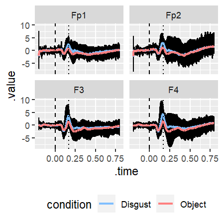

```r
A<-data_seg %>%
  select(Fp1,Fp2, F3, F4) %>%
  ggplot(aes(x = .time, y = .value)) +
  geom_line(aes(group = condition))  +
  stat_summary(
    fun = "mean", geom = "line", alpha = 1, size = 1,
    aes(color = condition),show.legend = TRUE
  ) +
  facet_wrap(~.key) +
  geom_vline(xintercept = 0, linetype = "dashed") +
  geom_vline(xintercept = .17, linetype = "dotted") +
  theme(legend.position = "bottom")+
  scale_color_manual(labels = c("Disgust", "Object"), values = c("#80bfff", "#ff8080"))
A
```

if you want an interactive plot, you can use the function `ggplotly` from the package `plotly`:

[figure not shown]

```r
pp <- plotly::ggplotly(A, width=300, height=300)
ppc <- htmltools::div( pp, align="center" )  # Result is now an HTML object
```

```r
htmltools::save_html( ppc, "test.html" )     # Use in place of htmlwidgets::saveWidget()
```

## Theory

### Multiple testing problem?

The aim is to test if the difference in brain signal during the two conditions is different from $0$ for each time point, i.e., $500$. If the full set of channels is considered, we also have tests for each channel, i.e., $27$, returning a total number of tests equals $500 \cdot 27$. Therefore, we have $500$ or $500 \cdot 27$ statistical tests to perform at group-level, so considering the **random subject effect**. The multiple testing problem is obvious, and correction methods such as Bonferroni or similar do not capture the time(-spatial) correlation structure of the statistical tests; it will be a conservative method.

The cluster mass method is then used, proposed by [Maris and Oostenveld, 2007](https://doi.org/10.1016/j.jneumeth.2007.03.024). It is based on **permutation theory**; it gains some power with respect to other procedures correcting at the (spatial-)temporal cluster level instead of at the level of single tests. It is similar to the cluster mass approach in the fMRI framework, but in this case, the *voxels*, i.e., the single object of the analysis, are expressed in terms of time-points or combination time-points/channels. The method can then gain some power with respect to some traditional conservative FWER correction methods exploiting the (spatial-)temporal structure of the data.

### Repeated Measures ANOVA Model

The cluster mass method is based on the **repeated measures ANOVA** model, i.e.,

$$y = 1_{N \times 1} \mu + X^{\eta} \eta + X^{\pi}\pi + X^{\eta \pi}\eta \pi + \epsilon$$

where $1_{N \times 1}$ is a matrix with ones and

1. $\mu$ is the **intercept**;
2. $y \in \mathbb{R}^{N \times 1}$ is the response variables, i.e., the **signal**, in our case $N = n_{subj} \times n_{stimuli} = 40$;
3. $X^{\eta} \in \mathbb{R}^{N \times n_{stimuli}}$ is the **design matrix** describing the **fixed effect** regarding the stimuli, and $\eta \in \mathbb{R}^{n_{stimuli} \times 1}$ the corresponding parameter of interest;
4. $X^{\pi} \in \mathbb{R}^{N \times n_{subj}}$ is the **design matrix** describing the **random effect** regarding the subjects, and $\pi \in \mathbb{R}^{n_{subj} \times 1}$ the corresponding parameter.
5. $X^{\eta \pi}$ is the **design matrix** describing the **interaction effects** between subjects and conditions, and $\eta \pi$ the corresponding parameter;
6. $\epsilon \in \mathbb{R}^{N \times 1}$ is the **error term** with $0$ mean and variance $\sigma^2 I_N$.

Therefore, $y \sim (1\mu + X^{\eta} \eta, \Sigma)$, $\pi \sim (0, \sigma^2_{\pi} I_{n_{subj}})$ and $\eta \pi \sim (0,\text{cov}(\eta \pi))$. (N.B: $\eta \pi$ is not the product between $\eta$ and $\pi$ but refers to the **interaction effects** between subjects and conditions).

We want to make inference on $\eta$, such that $H_0: \eta = 0$ vs $H_1: \eta \ne 0$. We do that using the **F statistic**, i.e.,

$$F = \dfrac{y^\top H_{X^{\eta}} y / (n_{stimuli} - 1)}{ y^\top H_{X^{\eta \pi}}y/(n_{stimuli} -1)(n_{subj} -1)}$$
where $H_{X}$ is the **projection matrix**, i.e., $H_{X} = X(X^\top X)^{-1} X^\top$. In order to compute this test, we use an alternative definition of $F$ based on the residuals:

$$F_r = \dfrac{r^\top H_{X^{\eta}} r / (n_{stimuli} - 1)}{ r^\top H_{X^{\eta \pi}}r/(n_{stimuli} -1)(n_{subj} -1)}$$

where $r = (H_{X^{\eta}} + H_{X^{\eta\pi}})y$. For further details, see [Kherad Pajouh and Renaud, 2014](https://link.springer.com/article/10.1007/s00362-014-0617-3).

So, let the group of permutation, including the identity transformation, $\mathcal{P}$, we use $r^\star = P r$, where $P \in \mathcal{P}$ to compute the null distribution of our test, i.e., $\mathcal{R}$, and then the p-value, i.e.,

$$\text{p-value} = \dfrac{1}{B} \sum_{F^\star_r \in \mathcal{R}} \mathbb{I}(|F^\star_r| \ge |F_r|)$$

if the two-tailed is considered, where $F^\star_r = f(r^\star)$.

We have this model for each time point $t \in \{1, \dots, 500\}$ and each channel, so finally we will have $n_{\text{time-points}} \times n_{\text{channels}}$ statistical tests/p-values (raw).

### Temporal Cluster mass

This method has been proposed by [Maris and Oostenveld, 2007](https://doi.org/10.1016/j.jneumeth.2007.03.024). It assumes that an effect will appear in clusters of adjacent time frames. Having statistics for each time point, we form these clusters using a threshold $\tau$ as follows:

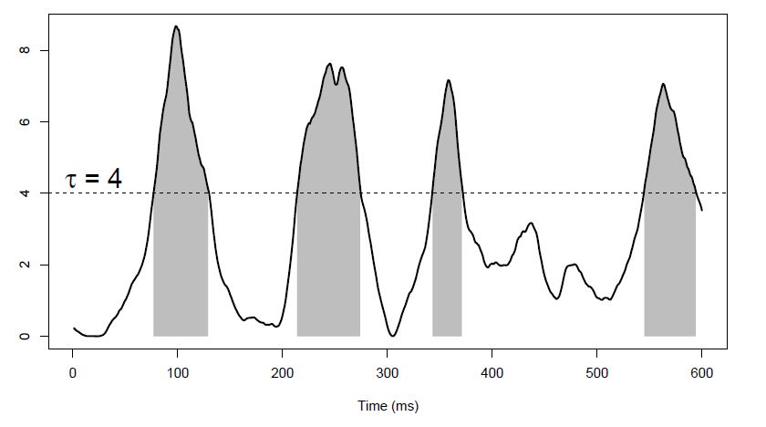

Example of cluster mass EEG from Frossard, 2019

All contiguous time points with statistics above this threshold define a single cluster $C_i$ with $i \in \{1, \dots, n_C\}$, where $n_C$ is the number of clusters found. For each time point in the same cluster $C_i$, we assign the same cluster mass statistic $m_i = f(C_i)$, where $f$ is the function that summarizes the statistics of the entire cluster. Typically, it is the sum of the $F$ statistics. The null distribution of the cluster mass $\mathcal{M}$ is computed by iterating the above process for each permutation. The contribution of a permutation to the cluster-mass null distribution is the maximum overall cluster mass of that permutation. To check the significance of the cluster $C_i$ of interest, we compare its cluster mass $m_i = f(C_i)$ with the cluster mass null distribution $\mathcal{M}$. Therefore, for each cluster $C_i$, we have the associated p-values computed as

$$p_i = \dfrac{1}{n_P} \sum_{m^\star \in \mathcal{M}} I\{m^\star \ge m_i\}$$

where $m^\star \in \mathcal{M}$ is then calculated given permutation statistics. This method makes sense when analysing EEG data because if a difference in brain activity is thought to occur at time $s$ for a given factor, then it is very likely that this difference will also occur at time $s + 1$ (or $s - 1$).

### Spatial-temporal Cluster mass

In this case, we use graph theory, where vertices represent channels and edges represent **relationships**. The adjacency must be defined using prior information, so a three-dimensional Euclidean distance between channels is used. Two channels are defined as adjacent if their Euclidean distance is less than the threshold $\delta$, where $\delta$ is the smallest Euclidean distance that yields an adjacent graph. This follows from the fact that there is no unconnected subgraph for a connected graph. The existence of subgraphs implies that some trials cannot be constructed in the same cluster, which is not a useful assumption for the present analysis ([Frossard and Renaud, 2018](https://cran.r-project.org/web/packages/permuco/vignettes/permuco_tutorial.pdf); Frossard, 2019).

Once we have a definition of spatial contiguity, we need to define temporal contiguity. We reproduce this graph $n_{\text{time-points}}$ times, and we have edges between pairs of two vertices associated to the same electrode if they are temporally adjacent. The final graph has a total number of vertices, i.e., number of tests, equals ($n_{\text{channels}} \times n_{\text{time-points}}$). The following figure shows an example with $64$ channels and $3$ time measures:

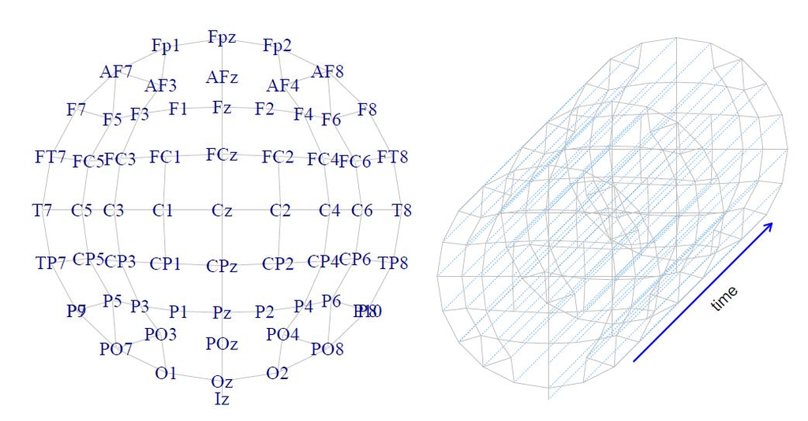

Example of graph of adjacency from Frossard, 2019

We then delete all the vertices in which statistics are below a threshold, e.g., the $95$ percentile of the null distribution of the $F$ statistics. So, we have a new graph composed of **multiple connected components**, where each connected component defines the spatial-temporal cluster. We compute for each spatial-temporal cluster the cluster-mass statistic as before.

The cluster-mass null distribution is calculated using permutations that preserve the spatial-temporal correlation structure of the statistical tests, i.e., no changing the position of the electrodes and mixing the time points. We construct a three-dimensional array, where the first dimension represents the design of our experiments (subjects of $\times$ stimuli), the second one the time points, and the third one the electrodes. So, we apply permutations only in the first dimension using the method proposed by [Kherad Pajouh and Renaud, 2014](https://link.springer.com/article/10.1007/s00362-014-0617-3).

## Application

In R, all of this is possible thanks to the `permuco` and `permuco4brain` packages developed by [Frossard and Renaud, 2018](https://cran.r-project.org/web/packages/permuco/vignettes/permuco_tutorial.pdf).

### Temporal Cluster-Mass

So, we select one channel from our dataset, e.g. the **Fp1**:

```r
Fp1 <- data_seg %>% select(Fp1)
```

```r
signal_Fp1 <- Fp1%>%
    signal_tbl()%>%
    group_by(.id)%>%
    nest()%>% #creates a list-column of 40 data frames having dim 500 x 2
    mutate(data = map(data,~as.matrix(.x[-1])))%>% #drop off the first column of each dataframe, i.e., we take the column oof the signal for channel Fp1
    pull(data)%>% #takes data created in mutate
    invoke(abind,.,along = 2)%>% #we merge each dataframe in order to have one db having dimension 500 x 40
    aperm(c(2,1)) #traspose
dim(signal_Fp1)
```

```
#> [1]  40 500
```

So, `signal_Fp1` is a data frame that expresses the channel **Fp1** signals under two conditions in $500$ time points for $20$ subjects.

2. Construct the $X^{\eta \pi}$, having dimensions $40 \times 2$:

```r
design <-
  segments_tbl(Fp1)%>%
  select(participant_id, condition)
dim(design)
```

```
#> [1] 40  2
```

3. Define the **repeated measures ANOVA formula**:

```r
f <- signal_Fp1 ~ condition + Error(participant_id/(condition))
```

In the formula, we need to specify the `Error(.)` term since we are dealing with a repeated measures design. We specify a subject-level random effect and a condition fixed effect nested within subjects.

Thanks to the `permuco` package, we can apply the temporal cluster-Mass for the channel **Fp1**:

```r
lm_Fp1 <- clusterlm(f,data = design)
summary(lm_Fp1)
```

```
#> Effect: condition.
#> Alternative Hypothesis: two.sided.
#> Statistic: fisher(1, 38).
#> Resample Method: Rd_kheradPajouh_renaud.
#> Number of Dependant Variables: 500.
#> Type of Resample: .
#> Number of Resamples: 5000.
#> Multiple Comparisons Procedure: clustermass.
#> Threshold: 4.098172.
#> Mass Function: the sum.
#> Table of clusters.
#>
#>   start end cluster mass P(>mass)
#> 1    47  48     10.49306   0.8410
#> 2   170 210    424.79648   0.0286
#> 3   217 225     55.56859   0.3172
#> 4   378 381     21.22319   0.7104
```

Here we can see:

- The threshold used to construct the temporal clusters, i.e., 4.0981717;
- The type of cluster mass function, i.e., the sum of single statistical tests time contiguous;
- When the cluster starts and ends, the value of the cluster mass and the associated corrected p-values.

For example, considering the first significant cluster, we can compute the cluster mass as:

```r
sum(lm_Fp1$multiple_comparison$condition$uncorrected$main[c(170:210), "statistic"])
```

```
#> [1] 424.7965
```

We can also plot the temporal clusters:

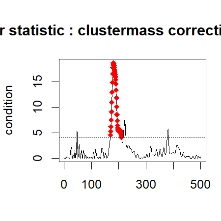

```r
plot(lm_Fp1)
```

The red dots represent the significant temporal cluster for the channel **Fp1** composed by the time points from $170$ to $210$ using a threshold equals $4.098$.

#### ARI in EEG cluster mass

However, our significant cluster says only that at least one test is different from $0$, we don’t know how many tests/time-points are significant (**spatial specificity paradox**). So, we can apply ARI to understand the lower bound of the number of true discovery proportion. The cluster is composed by the time points from $170$ to $210$, i.e., the size of the cluster is equal to $41$.

```r
praw <- lm_Fp1$multiple_comparison$condition$uncorrected$main[,2]
cluster <- c(170:210)

discoveries(hommel(praw), ix = cluster)/length(cluster)*100
```

```
#> [1] 29.26829
```

Therefore, we have at least 29.268$\%$ of true active time points in the cluster computed.

### Spatial-Temporal Cluster-Mass

1. Construct the $y$. We need to construct the three-dimensional **signal array**, having dimensions $40 \times 500 \times 27$:

```r
signal <-
    data_seg%>%
    signal_tbl()%>%
    group_by(.id)%>%
    nest()%>%
    mutate(data = map(data,~as.matrix(.x[-1])))%>%
    pull(data)%>%
    invoke(abind,.,along = 3)%>%
    aperm(c(3,1,2))

dim(signal)
```

```
#> [1]  40 500  27
```

2. Construct the $X^{\eta \pi}$, having dimensions $40 \times 2$:

```r
design <-
  segments_tbl(data_seg)%>%
  select(participant_id, condition)
dim(design)
```

```
#> [1] 40  2
```

3. Construct the **graph**, using $\delta = 53mm$ (the maximal distance for adjacency of two channels) and the function `position_to_graph` from the `permuco4brain` package:

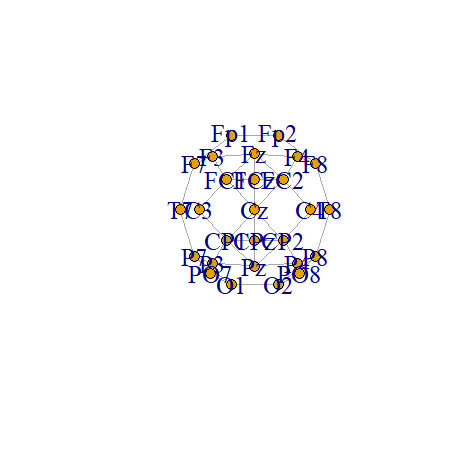

```r
graph <- position_to_graph(channels_tbl(data_seg), name = .channel, delta = 53,
                             x = .x, y = .y, z = .z)
plot(graph)
```

4. Define the **repeated measures ANOVA formula**:

```r
f <- signal ~ condition + Error(participant_id/(condition))
```

Finally, run the main function:

```r
model <- permuco4brain::brainperm(formula = f,
                                  data = design,
                                  graph = graph,
                                  np = 1000,
                                  multcomp = "clustermass",
                                  return_distribution = TRUE)
```

```
#> Computing Effect:
#> 1 (condition) of 1. Start at 2022-05-04 16:31:34.
```

where np indicates the number of permutation.

Then, we can analyze the output:

```r
print(model)
```

```
#> Effect: condition.
#> Alternative Hypothesis: two.sided.
#> Statistic: fisher(1, 38).
#> Resample Method: Rd_kheradPajouh_renaud.
#> Number of Dependant Variables: 13500.
#> Type of Resample: permutation.
#> Number of Resamples: 1000.
#> Multiple Comparisons Procedure: clustermass.
#> Threshold: 4.098172.
#> Mass Function: the sum.
#> Table of clusters.
#>
#>    Cluster id First sample Last sample N. chan. Main chan. Main chan. length N. test
#> 1           1           41          44        1         T7                 4       4
#> 2           2           47          48        1        Fp1                 2       2
#> 3           3          164         487       25         P8               298    1322
#> 4           4          260         265        1         P7                 6       6
#> 5           5          266         327        8        CPz                62     222
#> 6           6          274         277        1         P7                 4       4
#> 7           7          285         500        8         P7               183     666
#> 8           8          373         374        1        CP2                 2       2
#> 9           9          378         381        1        Fp1                 4       4
#> 10         10          498         500        1         P8                 3       3
#>     Clustermass P(>mass)
#> 1     22.922758    0.999
#> 2     10.493061    1.000
#> 3  15901.330605    0.001
#> 4     25.774934    0.998
#> 5   1085.206144    0.494
#> 6     16.838841    0.999
#> 7   5368.015395    0.053
#> 8      8.321318    1.000
#> 9     21.223185    0.999
#> 10    12.861519    1.000
```

```r
head(names(model$multiple_comparison$condition$clustermass$cluster$membership[which(as.vector(model$multiple_comparison$condition$clustermass$cluster$membership)==3)]))
```

```
#> [1] "P7_164"  "Pz_164"  "P7_165"  "Pz_165"  "P7_166"  "CPz_166"
```

You can see the significant cluster (in red) at fixed time points (e.g. 300) using plot:

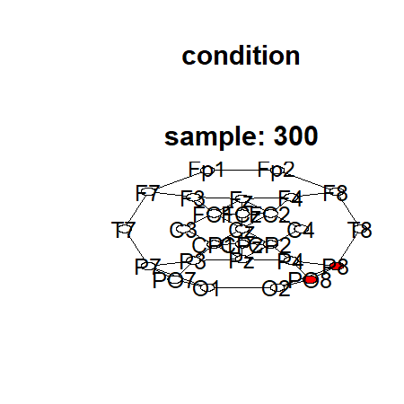

```r
plot(model, samples = 300)
```

and the significant cluster over time and over channels using:

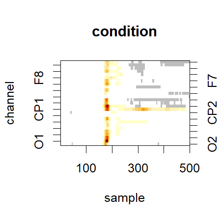

```r
image(model)
```

where the significant clusters are represented in a colour-scale and the non-significant one in grey. The white pixels are tests which statistic are below the threshold.

#### ARI in EEG cluster mass

However, our significant clusters say only that at least one combination channels/time-points is different from $0$, we do not know how many combinations are significant (**spatial specificity paradox**). So, we can apply ARI to understand the lower bound of the number of true discovery proportion:

```r
ARIeeg::ARIeeg(model = model)
```

```
#>       ID Total  clustermass pvalue False Null True Null Active Proportion
#>  [1,]  1     4    22.922758  0.999          0         4                 0
#>  [2,]  2     2    10.493061  1.000          0         2                 0
#>  [3,]  3  1322 15901.330605  0.001          0      1322                 0
#>  [4,]  4     6    25.774934  0.998          0         6                 0
#>  [5,]  5   222  1085.206144  0.494          0       222                 0
#>  [6,]  6     4    16.838841  0.999          0         4                 0
#>  [7,]  7   666  5368.015395  0.053          0       666                 0
#>  [8,]  8     2     8.321318  1.000          0         2                 0
#>  [9,]  9     4    21.223185  0.999          0         4                 0
#> [10,] 10     3    12.861519  1.000          0         3                 0
```

# References

- Maris, E., & Oostenveld, R. (2007). Nonparametric statistical testing of EEG-and MEG-data. Journal of neuroscience methods, 164(1), 177-190.
- Kherad-Pajouh, S., & Renaud, O. (2015). A general permutation approach for analyzing repeated measures ANOVA and mixed-model designs. Statistical Papers, 56(4), 947-967.
- Frossard, J. (2019). Permutation tests and multiple comparisons in the linear models and mixed linear models, with extension to experiments using electroencephalography. DOI: 10.13097/archive-ouverte/unige:125617.
- Frossard, J. & O. Renaud (2018). Permuco: Permutation Tests for Regression, (Repeated Measures) ANOVA/ANCOVA and Comparison of Signals. R Packages.